# Calcul of IBD in legacy datasets

MGH

2026-02-17

# 1 Set-up

```r
library(sf)
library(ggplot2)
library(ggpmisc)
library(tidyr)
library(tibble)
library(dplyr)
library(purrr)
library(units)
library("measurements")
library(geodist)
```

# 2 Pairwise distance between populations

So here, I calculate the distance in km between pairs of populations. Everything is saved into a list with an element corresponding to a dataset (the pairwise Fst are also stored into a list, that’s why!)

## 2.1 Calculate the distances for datasets with GPS coordinates

### 2.1.1 microsat datasets

```r
microsat_dist <- list.files("data_checked_ok/microsat/", full.names = TRUE)
```

```r
microsat_Dist_values_by_dataset <- list()

for (i in microsat_dist){
  #load coordinates of populations
  dataset <- read.csv(i,sep=";")
  dataset <- dataset %>% column_to_rownames("Pop") %>% as.matrix()

  #calculate the distance
  mat_dist <- geodist(dataset, measure = "geodesic") #measure in meter
  mat_dist <- mat_dist / 1000 #convert in km
  rownames(mat_dist) <- rownames(dataset)
  colnames(mat_dist) <- rownames(dataset)
  mat_dist

  #save that in a list
  name_dataset <- tools::file_path_sans_ext(basename(i))
  microsat_Dist_values_by_dataset[[name_dataset]] <- mat_dist
}
```

### 2.1.2 SNPs datasets

```r
snps_dist <- list.files("data_checked_ok/snps/", full.names = TRUE)
```

```r
snps_Dist_values_by_dataset <- list()

for (i in snps_dist){
  #load coordinates of populations
  dataset <- read.csv(i,sep=";")
  dataset <- dataset %>% column_to_rownames("Pop_final") %>% as.matrix()

  #calculate the distance
  mat_dist <- geodist(dataset, measure = "geodesic") #measure in meter
  mat_dist <- mat_dist / 1000 #convert in km
  rownames(mat_dist) <- rownames(dataset)
  colnames(mat_dist) <- rownames(dataset)
  mat_dist

  #save that in a list
  name_dataset <- tools::file_path_sans_ext(basename(i))
  snps_Dist_values_by_dataset[[name_dataset]] <- mat_dist
}
```

## 2.2 Add the distance matrix calculated by hand with ImageJ

```r
hand_calc_dist_mat <- list.files("data_checked_ok/dist_mat_hand_calc_with_ImageJ/", full.names = TRUE)
hand_calc_dist_mat
```

```
##  [1] "data_checked_ok/dist_mat_hand_calc_with_ImageJ/Canis_lupus_Silva_2018_K11.txt"
##  [2] "data_checked_ok/dist_mat_hand_calc_with_ImageJ/Canis_lupus_Szewczyk_2019.txt"
##  [3] "data_checked_ok/dist_mat_hand_calc_with_ImageJ/Cypripedium_calceolus_Gargiulo_2023.txt"
##  [4] "data_checked_ok/dist_mat_hand_calc_with_ImageJ/Mya_arenaria_DeNoia_2020.txt"
##  [5] "data_checked_ok/dist_mat_hand_calc_with_ImageJ/Passer_domesticus_Baalsrud_2013_pop_1994.txt"
##  [6] "data_checked_ok/dist_mat_hand_calc_with_ImageJ/Passer_domesticus_Baalsrud_2013_pop_2000.txt"
##  [7] "data_checked_ok/dist_mat_hand_calc_with_ImageJ/Passer_domesticus_Baalsrud_2013_pop_2006.txt"
##  [8] "data_checked_ok/dist_mat_hand_calc_with_ImageJ/Passer_domesticus_Hagen_2020.txt"
##  [9] "data_checked_ok/dist_mat_hand_calc_with_ImageJ/Rana_arvalis_Cox_2024.txt"
## [10] "data_checked_ok/dist_mat_hand_calc_with_ImageJ/Sardina_pilchardus_Antoniou_2023.txt"
## [11] "data_checked_ok/dist_mat_hand_calc_with_ImageJ/Symphonia_globulifera_Schmitt2021_Gargiulo2024.txt"
```

```r
microsat_hand_calc_dist_mat <- c("data_checked_ok/dist_mat_hand_calc_with_ImageJ/Canis_lupus_Silva_2018_K11.txt","data_checked_ok/dist_mat_hand_calc_with_ImageJ/Canis_lupus_Szewczyk_2019.txt", "data_checked_ok/dist_mat_hand_calc_with_ImageJ/Cypripedium_calceolus_Gargiulo_2023.txt", "data_checked_ok/dist_mat_hand_calc_with_ImageJ/Mya_arenaria_DeNoia_2020.txt","data_checked_ok/dist_mat_hand_calc_with_ImageJ/Passer_domesticus_Baalsrud_2013_pop_1994.txt", "data_checked_ok/dist_mat_hand_calc_with_ImageJ/Passer_domesticus_Baalsrud_2013_pop_2000.txt", "data_checked_ok/dist_mat_hand_calc_with_ImageJ/Passer_domesticus_Baalsrud_2013_pop_2006.txt", "data_checked_ok/dist_mat_hand_calc_with_ImageJ/Rana_arvalis_Cox_2024.txt")

snps_hand_calc_dist_mat <- c("data_checked_ok/dist_mat_hand_calc_with_ImageJ/Cypripedium_calceolus_Gargiulo_2023.txt", "data_checked_ok/dist_mat_hand_calc_with_ImageJ/Passer_domesticus_Hagen_2020.txt","data_checked_ok/dist_mat_hand_calc_with_ImageJ/Sardina_pilchardus_Antoniou_2023.txt", "data_checked_ok/dist_mat_hand_calc_with_ImageJ/Symphonia_globulifera_Schmitt2021_Gargiulo2024.txt")
```

```r
for (i in microsat_hand_calc_dist_mat){
  mat <- as.matrix(read.table(i, header = TRUE, row.names = 1, sep = "\t", na.strings = ""))
  mat[upper.tri(mat)] <- t(mat)[upper.tri(mat)]

  #save that in a list
  name_dataset <- tools::file_path_sans_ext(basename(i))
  microsat_Dist_values_by_dataset[[name_dataset]] <- mat

  #check
  #print(name_dataset)
  #print(mat)
}
```

Let’s add this in the SNPs list

```r
for (i in snps_hand_calc_dist_mat){
  mat <- as.matrix(read.table(i, header = TRUE, row.names = 1, sep = "\t", na.strings = ""))
  mat[upper.tri(mat)] <- t(mat)[upper.tri(mat)]

  #save that in a list
  name_dataset <- tools::file_path_sans_ext(basename(i))
  snps_Dist_values_by_dataset[[name_dataset]] <- mat

  #check
  #print(name_dataset)
  #print(mat)
}
```

## 2.3 Check our final distance matrixes

```r
names(microsat_Dist_values_by_dataset)
```

```
##  [1] "Alytes_obstetricans_Barratt_2024"
##  [2] "Antirrhinum_charidemi_HeuertzForrest_2024"
##  [3] "Coenagrion_mercuriale_Leveque_2024"
##  [4] "Gasterosteus_aculeatus_Raeymaekers_2008"
##  [5] "Graellsia_isabellae_GonzalesCastellano_2023"
##  [6] "Ursus_arctos_Kopatz_2021"
##  [7] "Canis_lupus_Silva_2018_K11"
##  [8] "Canis_lupus_Szewczyk_2019"
##  [9] "Cypripedium_calceolus_Gargiulo_2023"
## [10] "Mya_arenaria_DeNoia_2020"
## [11] "Passer_domesticus_Baalsrud_2013_pop_1994"
## [12] "Passer_domesticus_Baalsrud_2013_pop_2000"
## [13] "Passer_domesticus_Baalsrud_2013_pop_2006"
## [14] "Rana_arvalis_Cox_2024"
```

```r
names(snps_Dist_values_by_dataset)
```

```
##  [1] "Alytes_obstetricans_Barratt_2024"
##  [2] "Barbastella_barbastellus_Razgour_2024"
##  [3] "Coenagrion_mercuriale_Leveque_2024"
##  [4] "Fagus_sylvatica_Milesi_2024"
##  [5] "Pinus_pinaster_Milesi_2024"
##  [6] "Pinus_sylvestris_Milesi_2024"
##  [7] "Raja_clavata_Marandel_2020"
##  [8] "Ursus_arctos_Kopatz_2024"
##  [9] "Cypripedium_calceolus_Gargiulo_2023"
## [10] "Passer_domesticus_Hagen_2020"
## [11] "Sardina_pilchardus_Antoniou_2023"
## [12] "Symphonia_globulifera_Schmitt2021_Gargiulo2024"
```

and save these 2 lists

```r
save(microsat_Dist_values_by_dataset, file="microsat_Dist_values_by_dataset.Rdata")
save(snps_Dist_values_by_dataset, file="snps_Dist_values_by_dataset.Rdata")
```

# 3 IBD

## 3.1 Load the Fst pairwise

Load the pairwise matrices (already obtained from the Summary_statistics files)

```r
#SNPs
load("C:/Users/mgharribey/Documents/These_BIOGECO/Article1/analyses_article1/Summary_stats_genetic/Genetic_data_v4/Summary_statistics/snps_Pairwise_values_by_dataset.Rdata")
names(snps_Pairwise_values_by_dataset)
```

```
##  [1] "gen_Barbastella_barbastellus_Razgour_2024"
##  [2] "gen_Coenagrion_mercuriale_Leveque_2024"
##  [3] "gen_Cypripedium_calceolus_Gargiulo_2023"
##  [4] "gen_Fagus_sylvatica_Milesi_2024"
##  [5] "gen_Passer_domesticus_Hagen_2020"
##  [6] "gen_Pinus_pinaster_Milesi_2024"
##  [7] "gen_Pinus_sylvestris_Milesi_2024"
##  [8] "gen_Raja_clavata_Marandel_2020"
##  [9] "gen_Sardina_pilchardus_Antoniou_2023"
## [10] "gen_Symphonia_globulifera_Schmitt2021_Gargiulo2024"
```

```r
#Microsat
load("C:/Users/mgharribey/Documents/These_BIOGECO/Article1/analyses_article1/Summary_stats_genetic/Genetic_data_v2/FINAL_datasets/microsat_Pairwise_values_by_dataset.Rdata")
names(Pairwise_values_by_dataset_microsat)
```

```
##  [1] "genind_Alytes_obstetricans_Barratt_2024"
##  [2] "genind_Antirrhinum_charidemi_HeuertzForrest_2024"
##  [3] "genind_Canis_lupus_Silva_2018_K11"
##  [4] "genind_Canis_lupus_Szewczyk_2019"
##  [5] "genind_Coenagrion_mercuriale_Leveque_2024"
##  [6] "genind_Cypripedium_calceolus_Gargiulo_2023"
##  [7] "genind_Gasterosteus_aculeatus_Raeymaekers_2008"
##  [8] "genind_Graellsia_isabellae_GonzalesCastellano_2023"
##  [9] "genind_Mya_arenaria_DeNoia_2020"
## [10] "genind_Passer_domesticus_Baalsrud_2013_pop_1994"
## [11] "genind_Passer_domesticus_Baalsrud_2013_pop_2000"
## [12] "genind_Passer_domesticus_Baalsrud_2013_pop_2006"
## [13] "genind_Rana_arvalis_Cox_2024"
## [14] "genind_Ursus_arctos_Kopatz_2021"
```

Some adjustments –> improve the name of datasets

```r
#SNPs
names(snps_Pairwise_values_by_dataset) <- sub("^gen_", "", names(snps_Pairwise_values_by_dataset))
names(snps_Pairwise_values_by_dataset)
```

```
##  [1] "Barbastella_barbastellus_Razgour_2024"
##  [2] "Coenagrion_mercuriale_Leveque_2024"
##  [3] "Cypripedium_calceolus_Gargiulo_2023"
##  [4] "Fagus_sylvatica_Milesi_2024"
##  [5] "Passer_domesticus_Hagen_2020"
##  [6] "Pinus_pinaster_Milesi_2024"
##  [7] "Pinus_sylvestris_Milesi_2024"
##  [8] "Raja_clavata_Marandel_2020"
##  [9] "Sardina_pilchardus_Antoniou_2023"
## [10] "Symphonia_globulifera_Schmitt2021_Gargiulo2024"
```

```r
#microsat
names(Pairwise_values_by_dataset_microsat) <- sub("^genind_", "", names(Pairwise_values_by_dataset_microsat))
names(Pairwise_values_by_dataset_microsat)
```

```
##  [1] "Alytes_obstetricans_Barratt_2024"
##  [2] "Antirrhinum_charidemi_HeuertzForrest_2024"
##  [3] "Canis_lupus_Silva_2018_K11"
##  [4] "Canis_lupus_Szewczyk_2019"
##  [5] "Coenagrion_mercuriale_Leveque_2024"
##  [6] "Cypripedium_calceolus_Gargiulo_2023"
##  [7] "Gasterosteus_aculeatus_Raeymaekers_2008"
##  [8] "Graellsia_isabellae_GonzalesCastellano_2023"
##  [9] "Mya_arenaria_DeNoia_2020"
## [10] "Passer_domesticus_Baalsrud_2013_pop_1994"
## [11] "Passer_domesticus_Baalsrud_2013_pop_2000"
## [12] "Passer_domesticus_Baalsrud_2013_pop_2006"
## [13] "Rana_arvalis_Cox_2024"
## [14] "Ursus_arctos_Kopatz_2021"
```

## 3.2 Table pairwise Fst/dist

### 3.2.1 Microsat

```r
microsat_datasets <- names(Pairwise_values_by_dataset_microsat)
```

```r
microsat_df_pop_2by2_Fst_dist <- list()

for (i in microsat_datasets){
  #turn matrix fst in a dataframe
  pairwise_fst <- as.matrix(Pairwise_values_by_dataset_microsat[[i]]$fst)
  mat_low <- lower.tri(pairwise_fst, diag = FALSE)
  pairwise_fst_df <- data.frame(pop1  = rownames(pairwise_fst)[row(pairwise_fst)[mat_low]],
                          pop2  = colnames(pairwise_fst)[col(pairwise_fst)[mat_low]],
                          Fst = as.numeric(pairwise_fst[mat_low]),
                          row.names = NULL,
                          stringsAsFactors = FALSE)

  #turn matrix dist in a dataframe
  pairwise_dist <- as.matrix(microsat_Dist_values_by_dataset[[i]])
  mat_low2 <- lower.tri(pairwise_dist, diag = FALSE)
  pairwise_dist_df <- data.frame(pop1  = rownames(pairwise_dist)[row(pairwise_dist)[mat_low2]],
                          pop2  = colnames(pairwise_dist)[col(pairwise_dist)[mat_low2]],
                          Dist_km = as.numeric(pairwise_dist[mat_low2]),
                          row.names = NULL,
                          stringsAsFactors = FALSE)

  #concat
  pairwise_fst_df  <- pairwise_fst_df %>%
  mutate(popA  = pmin(pop1, pop2), #this is to make sure that we have the 2 columns organized the same way as pop1-pop2 and not pop2-pop1
         popB = pmax(pop1, pop2))%>%
  select(-pop1, -pop2)
pairwise_dist_df <- pairwise_dist_df  %>%
  mutate(popA  = pmin(pop1, pop2),
         popB = pmax(pop1, pop2))%>%
  select(-pop1, -pop2)
  Fst_dist_df <- left_join(pairwise_dist_df,pairwise_fst_df,by=c("popA", "popB"))

  #store this dataframe in a list
  microsat_df_pop_2by2_Fst_dist[[i]] <- Fst_dist_df
}
```

Checking if there are some problem

```r
has_NA <- sapply(microsat_df_pop_2by2_Fst_dist, anyNA)
names(microsat_df_pop_2by2_Fst_dist)[has_NA]
```

```
## [1] "Canis_lupus_Silva_2018_K11"
## [2] "Canis_lupus_Szewczyk_2019"
## [3] "Mya_arenaria_DeNoia_2020"
## [4] "Passer_domesticus_Baalsrud_2013_pop_1994"
## [5] "Passer_domesticus_Baalsrud_2013_pop_2000"
## [6] "Passer_domesticus_Baalsrud_2013_pop_2006"
```

Cases with problems:

```r
i="Canis_lupus_Silva_2018_K11"

#turn matrix fst in a dataframe
  pairwise_fst <- as.matrix(Pairwise_values_by_dataset_microsat[[i]]$fst)
  mat_low <- lower.tri(pairwise_fst, diag = FALSE)
  pairwise_fst_df <- data.frame(pop1  = rownames(pairwise_fst)[row(pairwise_fst)[mat_low]],
                          pop2  = colnames(pairwise_fst)[col(pairwise_fst)[mat_low]],
                          Fst = as.numeric(pairwise_fst[mat_low]),
                          row.names = NULL,
                          stringsAsFactors = FALSE)
pairwise_fst_df
```

| pop1 | pop2 | Fst |
| --- | --- | --- |
| W Galicia | C Asturias | 0.1185111 |
| E Asturias | C Asturias | 0.1269629 |
| E Asturias | W Galicia | 0.1613986 |

```r
  #turn matrix dist in a dataframe
  pairwise_dist <- as.matrix(microsat_Dist_values_by_dataset[[i]])
  mat_low2 <- lower.tri(pairwise_dist, diag = FALSE)
  pairwise_dist_df <- data.frame(pop1  = rownames(pairwise_dist)[row(pairwise_dist)[mat_low2]],
                          pop2  = colnames(pairwise_dist)[col(pairwise_dist)[mat_low2]],
                          Dist_km = as.numeric(pairwise_dist[mat_low2]),
                          row.names = NULL,
                          stringsAsFactors = FALSE)
pairwise_dist_df
```

| pop1 | pop2 | Dist_km |
| --- | --- | --- |
| W Galicia | C.Asturias | 160 |
| E Asturias | C.Asturias | 80 |
| E Asturias | W.Galicia | 230 |

```r
pairwise_dist_df$pop2 <- gsub("\\.", " ", pairwise_dist_df$pop2)
pairwise_dist_df
```

| pop1 | pop2 | Dist_km |
| --- | --- | --- |
| W Galicia | C Asturias | 160 |
| E Asturias | C Asturias | 80 |
| E Asturias | W Galicia | 230 |

```r
  #concat
pairwise_fst_df  <- pairwise_fst_df %>%
  mutate(popA  = pmin(pop1, pop2),
         popB = pmax(pop1, pop2))%>%
  select(-pop1, -pop2)
pairwise_dist_df <- pairwise_dist_df  %>%
  mutate(popA  = pmin(pop1, pop2),
         popB = pmax(pop1, pop2))%>%
  select(-pop1, -pop2)
  Fst_dist_df <- left_join(pairwise_dist_df,pairwise_fst_df,by=c("popA", "popB"))

  #store this dataframe in a list
  microsat_df_pop_2by2_Fst_dist[[i]] <- Fst_dist_df
  microsat_df_pop_2by2_Fst_dist[[i]]
```

| Dist_km | popA | popB | Fst |
| --- | --- | --- | --- |
| 160 | C Asturias | W Galicia | 0.1185111 |
| 80 | C Asturias | E Asturias | 0.1269629 |
| 230 | E Asturias | W Galicia | 0.1613986 |

```r
i="Canis_lupus_Szewczyk_2019"

#turn matrix fst in a dataframe
  pairwise_fst <- as.matrix(Pairwise_values_by_dataset_microsat[[i]]$fst)
  mat_low <- lower.tri(pairwise_fst, diag = FALSE)
  pairwise_fst_df <- data.frame(pop1  = rownames(pairwise_fst)[row(pairwise_fst)[mat_low]],
                          pop2  = colnames(pairwise_fst)[col(pairwise_fst)[mat_low]],
                          Fst = as.numeric(pairwise_fst[mat_low]),
                          row.names = NULL,
                          stringsAsFactors = FALSE)
pairwise_fst_df
```

| pop1 | pop2 | Fst |
| --- | --- | --- |
| WPL II | WPL I | 0.0202801281 |
| NWPL | WPL I | 0.0172502229 |
| NEPL I | WPL I | 0.0271111172 |
| NEPL II | WPL I | 0.0516541711 |
| LT | WPL I | 0.0798068785 |
| SEPL | WPL I | 0.0986340176 |
| CarpMTS | WPL I | 0.1544157065 |
| NWPL | WPL II | -0.0003552026 |
| NEPL I | WPL II | 0.0156645561 |
| NEPL II | WPL II | 0.0265297332 |

[output cut: 18 more lines]

```r
  #turn matrix dist in a dataframe
  pairwise_dist <- as.matrix(microsat_Dist_values_by_dataset[[i]])
  mat_low2 <- lower.tri(pairwise_dist, diag = FALSE)
  pairwise_dist_df <- data.frame(pop1  = rownames(pairwise_dist)[row(pairwise_dist)[mat_low2]],
                          pop2  = colnames(pairwise_dist)[col(pairwise_dist)[mat_low2]],
                          Dist_km = as.numeric(pairwise_dist[mat_low2]),
                          row.names = NULL,
                          stringsAsFactors = FALSE)
pairwise_dist_df
```

| pop1 | pop2 | Dist_km |
| --- | --- | --- |
| WPL II | WPL.I | 410 |
| NWPL | WPL.I | 552 |
| NEPL I | WPL.I | 640 |
| NEPL II | WPL.I | 835 |
| LT | WPL.I | 1207 |
| SEPL | WPL.I | 740 |
| CarpMTS | WPL.I | 640 |
| NWPL | WPL.II | 303 |
| NEPL I | WPL.II | 552 |
| NEPL II | WPL.II | 902 |

[output cut: 18 more lines]

```r
pairwise_dist_df$pop2 <- gsub("\\.", " ", pairwise_dist_df$pop2)
pairwise_dist_df
```

| pop1 | pop2 | Dist_km |
| --- | --- | --- |
| WPL II | WPL I | 410 |
| NWPL | WPL I | 552 |
| NEPL I | WPL I | 640 |
| NEPL II | WPL I | 835 |
| LT | WPL I | 1207 |
| SEPL | WPL I | 740 |
| CarpMTS | WPL I | 640 |
| NWPL | WPL II | 303 |
| NEPL I | WPL II | 552 |
| NEPL II | WPL II | 902 |

[output cut: 18 more lines]

```r
  #concat
pairwise_fst_df  <- pairwise_fst_df %>%
  mutate(popA  = pmin(pop1, pop2),
         popB = pmax(pop1, pop2))%>%
  select(-pop1, -pop2)
pairwise_dist_df <- pairwise_dist_df  %>%
  mutate(popA  = pmin(pop1, pop2),
         popB = pmax(pop1, pop2))%>%
  select(-pop1, -pop2)
  Fst_dist_df <- left_join(pairwise_dist_df,pairwise_fst_df,by=c("popA", "popB"))

  #store this dataframe in a list
  microsat_df_pop_2by2_Fst_dist[[i]] <- Fst_dist_df
  microsat_df_pop_2by2_Fst_dist[[i]]
```

| Dist_km | popA | popB | Fst |
| --- | --- | --- | --- |
| 410 | WPL I | WPL II | 0.0202801281 |
| 552 | NWPL | WPL I | 0.0172502229 |
| 640 | NEPL I | WPL I | 0.0271111172 |
| 835 | NEPL II | WPL I | 0.0516541711 |
| 1207 | LT | WPL I | 0.0798068785 |
| 740 | SEPL | WPL I | 0.0986340176 |
| 640 | CarpMTS | WPL I | 0.1544157065 |
| 303 | NWPL | WPL II | -0.0003552026 |
| 552 | NEPL I | WPL II | 0.0156645561 |
| 902 | NEPL II | WPL II | 0.0265297332 |

[output cut: 18 more lines]

```r
i="Mya_arenaria_DeNoia_2020"

#turn matrix fst in a dataframe
  pairwise_fst <- as.matrix(Pairwise_values_by_dataset_microsat[[i]]$fst)
  mat_low <- lower.tri(pairwise_fst, diag = FALSE)
  pairwise_fst_df <- data.frame(pop1  = rownames(pairwise_fst)[row(pairwise_fst)[mat_low]],
                          pop2  = colnames(pairwise_fst)[col(pairwise_fst)[mat_low]],
                          Fst = as.numeric(pairwise_fst[mat_low]),
                          row.names = NULL,
                          stringsAsFactors = FALSE)
  #pb comes because pb with pop name that was updated since
  new_pop_name <- c("K" = "ITA",
                    "Com_It" = "PLY",
                    "E"="TEX",
                    "Kiel_Germ"="KIE",
                    "SanAndr_UK"="SAN",
                    "H"="LIS",
                    "Bre_Fr"="BRE",
                    "LCt_Fr"="LCT")
  pairwise_fst_df <- pairwise_fst_df %>%
  mutate(pop1 = recode(pop1, !!!new_pop_name, .default = pop1),
          pop2 = recode(pop2, !!!new_pop_name, .default = pop2))

  #turn matrix dist in a dataframe
  pairwise_dist <- as.matrix(microsat_Dist_values_by_dataset[[i]])
  mat_low2 <- lower.tri(pairwise_dist, diag = FALSE)
  pairwise_dist_df <- data.frame(pop1  = rownames(pairwise_dist)[row(pairwise_dist)[mat_low2]],
                          pop2  = colnames(pairwise_dist)[col(pairwise_dist)[mat_low2]],
                          Dist_km = as.numeric(pairwise_dist[mat_low2]),
                          row.names = NULL,
                          stringsAsFactors = FALSE)
  pairwise_dist_df
```

| pop1 | pop2 | Dist_km |
| --- | --- | --- |
| BRE | LIS | 1171 |
| ITA | LIS | 1939 |
| PLY | LIS | 1350 |
| LCT | LIS | 1572 |
| TEX | LIS | 1932 |
| KIE | LIS | 2333 |
| SAN | LIS | 2024 |
| ITA | BRE | 1342 |
| PLY | BRE | 196 |
| LCT | BRE | 472 |

[output cut: 18 more lines]

```r
  #concat
pairwise_fst_df  <- pairwise_fst_df %>%
  mutate(popA  = pmin(pop1, pop2),
         popB = pmax(pop1, pop2))%>%
  select(-pop1, -pop2)
pairwise_dist_df <- pairwise_dist_df  %>%
  mutate(popA  = pmin(pop1, pop2),
         popB = pmax(pop1, pop2))%>%
  select(-pop1, -pop2)
  Fst_dist_df <- left_join(pairwise_dist_df,pairwise_fst_df,by=c("popA", "popB"))

  #store this dataframe in a list
  microsat_df_pop_2by2_Fst_dist[[i]] <- Fst_dist_df
  microsat_df_pop_2by2_Fst_dist[[i]]
```

| Dist_km | popA | popB | Fst |
| --- | --- | --- | --- |
| 1171 | BRE | LIS | 0.06744730 |
| 1939 | ITA | LIS | 0.11139497 |
| 1350 | LIS | PLY | 0.05848296 |
| 1572 | LCT | LIS | 0.04400856 |
| 1932 | LIS | TEX | 0.03588782 |
| 2333 | KIE | LIS | 0.03790099 |
| 2024 | LIS | SAN | 0.09768354 |
| 1342 | BRE | ITA | 0.11275957 |
| 196 | BRE | PLY | 0.03845509 |
| 472 | BRE | LCT | 0.08818396 |

[output cut: 18 more lines]

```r
passer_datasets <- c("Passer_domesticus_Baalsrud_2013_pop_1994","Passer_domesticus_Baalsrud_2013_pop_2000","Passer_domesticus_Baalsrud_2013_pop_2006")

for (i in passer_datasets){
  #turn matrix fst in a dataframe
  pairwise_fst <- as.matrix(Pairwise_values_by_dataset_microsat[[i]]$fst)
  mat_low <- lower.tri(pairwise_fst, diag = FALSE)
  pairwise_fst_df <- data.frame(pop1  = rownames(pairwise_fst)[row(pairwise_fst)[mat_low]],
                          pop2  = colnames(pairwise_fst)[col(pairwise_fst)[mat_low]],
                          Fst = as.numeric(pairwise_fst[mat_low]),
                          row.names = NULL,
                          stringsAsFactors = FALSE)

  #turn matrix dist in a dataframe
  pairwise_dist <- as.matrix(microsat_Dist_values_by_dataset[[i]])
  mat_low2 <- lower.tri(pairwise_dist, diag = FALSE)
  pairwise_dist_df <- data.frame(pop1  = rownames(pairwise_dist)[row(pairwise_dist)[mat_low2]],
                          pop2  = colnames(pairwise_dist)[col(pairwise_dist)[mat_low2]],
                          Dist_km = as.numeric(pairwise_dist[mat_low2]),
                          row.names = NULL,
                          stringsAsFactors = FALSE)
  pairwise_dist_df$pop2 <- gsub("\\.", "-", pairwise_dist_df$pop2)
  pairwise_dist_df

  #concat
  pairwise_fst_df  <- pairwise_fst_df %>% mutate(popA  = pmin(pop1, pop2),
                                                  popB = pmax(pop1, pop2)) %>% select(-pop1, -pop2)
  pairwise_dist_df <- pairwise_dist_df  %>% mutate(popA  = pmin(pop1, pop2),
                                                    popB = pmax(pop1, pop2))%>% select(-pop1, -pop2)
  Fst_dist_df <- left_join(pairwise_fst_df,pairwise_dist_df,by=c("popA", "popB")) #careful, order exchanged!!! because distance matrixes contains all the island while according the year, not exactly the same

  #store this dataframe in a list
  microsat_df_pop_2by2_Fst_dist[[i]] <- Fst_dist_df
  microsat_df_pop_2by2_Fst_dist[[i]]
}
```

Now, look again at the problems:

```r
has_NA <- sapply(microsat_df_pop_2by2_Fst_dist, anyNA)
names(microsat_df_pop_2by2_Fst_dist)[has_NA]
```

```
## character(0)
```

If null –> then it’s all good :)

### 3.2.2 SNPs

```r
load("C:/Users/mgharribey/Documents/These_BIOGECO/Article1/analyses_article1/Summary_stats_genetic/Genetic_data_v3/Geographic_measures/snps_Dist_values_by_dataset.Rdata")
names(snps_Dist_values_by_dataset) <- c("Barbastella_barbastellus_Razgour_2024",
                                        "Coenagrion_mercuriale_Leveque_2024",
                                        "Fagus_sylvatica_Milesi_2024",
                                        "Pinus_pinaster_Milesi_2024",
                                        "Pinus_sylvestris_Milesi_2024",
                                        "Raja_clavata_Marandel_2020",
                                        "Sardina_pilchardus_Antoniou_2023",
                                        "Passer_domesticus_Hagen_2020",
                                        "Cypripedium_calceolus_Gargiulo_2023")
names(snps_Dist_values_by_dataset)
```

```
## [1] "Barbastella_barbastellus_Razgour_2024"
## [2] "Coenagrion_mercuriale_Leveque_2024"
## [3] "Fagus_sylvatica_Milesi_2024"
## [4] "Pinus_pinaster_Milesi_2024"
## [5] "Pinus_sylvestris_Milesi_2024"
## [6] "Raja_clavata_Marandel_2020"
## [7] "Sardina_pilchardus_Antoniou_2023"
## [8] "Passer_domesticus_Hagen_2020"
## [9] "Cypripedium_calceolus_Gargiulo_2023"
```

```r
snps_datasets <- names(snps_Pairwise_values_by_dataset)
snps_datasets
```

```
##  [1] "Barbastella_barbastellus_Razgour_2024"
##  [2] "Coenagrion_mercuriale_Leveque_2024"
##  [3] "Cypripedium_calceolus_Gargiulo_2023"
##  [4] "Fagus_sylvatica_Milesi_2024"
##  [5] "Passer_domesticus_Hagen_2020"
##  [6] "Pinus_pinaster_Milesi_2024"
##  [7] "Pinus_sylvestris_Milesi_2024"
##  [8] "Raja_clavata_Marandel_2020"
##  [9] "Sardina_pilchardus_Antoniou_2023"
## [10] "Symphonia_globulifera_Schmitt2021_Gargiulo2024"
```

```r
snps_datasets <- snps_datasets[snps_datasets != ("Symphonia_globulifera_Schmitt2021_Gargiulo2024")]
```

```r
snps_df_pop_2by2_Fst_dist <- list()

for (i in snps_datasets){
  #turn matrix fst in a dataframe
  pairwise_fst <- as.matrix(snps_Pairwise_values_by_dataset[[i]]$fst)
  mat_low <- lower.tri(pairwise_fst, diag = FALSE)
  pairwise_fst_df <- data.frame(pop1  = rownames(pairwise_fst)[row(pairwise_fst)[mat_low]],
                          pop2  = colnames(pairwise_fst)[col(pairwise_fst)[mat_low]],
                          Fst = as.numeric(pairwise_fst[mat_low]),
                          row.names = NULL,
                          stringsAsFactors = FALSE)

  #turn matrix dist in a dataframe
  pairwise_dist <- as.matrix(snps_Dist_values_by_dataset[[i]])
  mat_low2 <- lower.tri(pairwise_dist, diag = FALSE)
  pairwise_dist_df <- data.frame(pop1  = rownames(pairwise_dist)[row(pairwise_dist)[mat_low2]],
                          pop2  = colnames(pairwise_dist)[col(pairwise_dist)[mat_low2]],
                          Dist_km = as.numeric(pairwise_dist[mat_low2]),
                          row.names = NULL,
                          stringsAsFactors = FALSE)

  #concat
    pairwise_fst_df  <- pairwise_fst_df %>%
  mutate(popA  = pmin(pop1, pop2), #this is to make sure that we have the 2 columns organized the same way as pop1-pop2 and not pop2-pop1
         popB = pmax(pop1, pop2))%>%
  select(-pop1, -pop2)
pairwise_dist_df <- pairwise_dist_df  %>%
  mutate(popA  = pmin(pop1, pop2),
         popB = pmax(pop1, pop2))%>%
  select(-pop1, -pop2)
  Fst_dist_df <- left_join(pairwise_dist_df,pairwise_fst_df,by=c("popA", "popB"))

  #store this dataframe in a list
  snps_df_pop_2by2_Fst_dist[[i]] <- Fst_dist_df
}
```

```r
has_NA <- sapply(snps_df_pop_2by2_Fst_dist, anyNA)
names(snps_df_pop_2by2_Fst_dist)[has_NA]
```

```
## [1] "Coenagrion_mercuriale_Leveque_2024"  "Cypripedium_calceolus_Gargiulo_2023"
## [3] "Fagus_sylvatica_Milesi_2024"         "Passer_domesticus_Hagen_2020"
## [5] "Pinus_pinaster_Milesi_2024"          "Raja_clavata_Marandel_2020"
## [7] "Sardina_pilchardus_Antoniou_2023"
```

```r
i="Cypripedium_calceolus_Gargiulo_2023"

  #turn matrix fst in a dataframe
  pairwise_fst <- as.matrix(snps_Pairwise_values_by_dataset[[i]]$fst)
  mat_low <- lower.tri(pairwise_fst, diag = FALSE)
  pairwise_fst_df <- data.frame(pop1  = rownames(pairwise_fst)[row(pairwise_fst)[mat_low]],
                          pop2  = colnames(pairwise_fst)[col(pairwise_fst)[mat_low]],
                          Fst = as.numeric(pairwise_fst[mat_low]),
                          row.names = NULL,
                          stringsAsFactors = FALSE)
  new_pop_name <- c("EK"="Korgessaare",
                    "EU"="Ussisoo")
  pairwise_fst_df <- pairwise_fst_df %>%
  mutate(pop1 = recode(pop1, !!!new_pop_name, .default = pop1),
          pop2 = recode(pop2, !!!new_pop_name, .default = pop2))
  #turn matrix dist in a dataframe
  pairwise_dist <- as.matrix(snps_Dist_values_by_dataset[[i]])
  mat_low2 <- lower.tri(pairwise_dist, diag = FALSE)
  pairwise_dist_df <- data.frame(pop1  = rownames(pairwise_dist)[row(pairwise_dist)[mat_low2]],
                          pop2  = colnames(pairwise_dist)[col(pairwise_dist)[mat_low2]],
                          Dist_km = as.numeric(pairwise_dist[mat_low2]),
                          row.names = NULL,
                          stringsAsFactors = FALSE)

  #concat
    pairwise_fst_df  <- pairwise_fst_df %>%
  mutate(popA  = pmin(pop1, pop2), #this is to make sure that we have the 2 columns organized the same way as pop1-pop2 and not pop2-pop1
         popB = pmax(pop1, pop2))%>%
  select(-pop1, -pop2)
pairwise_dist_df <- pairwise_dist_df  %>%
  mutate(popA  = pmin(pop1, pop2),
         popB = pmax(pop1, pop2))%>%
  select(-pop1, -pop2)
  Fst_dist_df <- left_join(pairwise_dist_df,pairwise_fst_df,by=c("popA", "popB"))

  #store this dataframe in a list
  snps_df_pop_2by2_Fst_dist[[i]] <- Fst_dist_df
```

```r
i="Passer_domesticus_Hagen_2020"

  #turn matrix fst in a dataframe
  pairwise_fst <- as.matrix(snps_Pairwise_values_by_dataset[[i]]$fst)
  mat_low <- lower.tri(pairwise_fst, diag = FALSE)
  pairwise_fst_df <- data.frame(pop1  = rownames(pairwise_fst)[row(pairwise_fst)[mat_low]],
                          pop2  = colnames(pairwise_fst)[col(pairwise_fst)[mat_low]],
                          Fst = as.numeric(pairwise_fst[mat_low]),
                          row.names = NULL,
                          stringsAsFactors = FALSE)

  #turn matrix dist in a dataframe
  pairwise_dist <- as.matrix(snps_Dist_values_by_dataset[[i]])
  mat_low2 <- lower.tri(pairwise_dist, diag = FALSE)
  pairwise_dist_df <- data.frame(pop1  = rownames(pairwise_dist)[row(pairwise_dist)[mat_low2]],
                          pop2  = colnames(pairwise_dist)[col(pairwise_dist)[mat_low2]],
                          Dist_km = as.numeric(pairwise_dist[mat_low2]),
                          row.names = NULL,
                          stringsAsFactors = FALSE)
  pairwise_dist_df
```

| pop1 | pop2 | Dist_km |
| --- | --- | --- |
| Hestmannoy | Gjaroy | 13 |
| IndreKvaroy | Gjaroy | 16 |
| Luroy | Gjaroy | 28 |
| Onoy | Gjaroy | 23 |
| Selvaer | Gjaroy | 35 |
| Traena | Gjaroy | 46 |
| Ytre_Kvaroy | Gjaroy | 17 |
| Myken | Gjaroy | 28 |
| Nesoy | Gjaroy | 17 |
| Sleneset | Gjaroy | 35 |

[output cut: 68 more lines]

```r
  #concat
  pairwise_fst_df  <- pairwise_fst_df %>% mutate(popA  = pmin(pop1, pop2),
                                                  popB = pmax(pop1, pop2)) %>% select(-pop1, -pop2)
  pairwise_dist_df <- pairwise_dist_df  %>% mutate(popA  = pmin(pop1, pop2),
                                                    popB = pmax(pop1, pop2))%>% select(-pop1, -pop2)
  Fst_dist_df <- left_join(pairwise_fst_df,pairwise_dist_df,by=c("popA", "popB")) #careful, order exchanged!!! because distance matrixes contains all the island while according the year, not exactly the same

  #store this dataframe in a list
  snps_df_pop_2by2_Fst_dist[[i]] <- Fst_dist_df
  snps_df_pop_2by2_Fst_dist[[i]]
```

| Fst | popA | popB | Dist_km |
| --- | --- | --- | --- |
| 0.05745839 | Aldra | Hestmannoy | 17 |
| 0.01186592 | Hestmannoy | IndreKvaroy | 8 |
| 0.02314461 | Hestmannoy | Nesoy | 9 |
| 0.02632461 | Hestmannoy | Leka | NA |
| 0.02320553 | Hestmannoy | Vega | NA |
| 0.01175715 | Gjaroy | Hestmannoy | 13 |
| 0.02947233 | Hestmannoy | Myken | 29 |
| 0.05891591 | Aldra | IndreKvaroy | 10 |
| 0.06939539 | Aldra | Nesoy | 26 |
| 0.06514775 | Aldra | Leka | NA |

[output cut: 18 more lines]

```r
# 2 pop are missing from the mapping Leka and Vega so for now, let's look at the results without them
```

```r
i="Sardina_pilchardus_Antoniou_2023"

  #turn matrix fst in a dataframe
  pairwise_fst <- as.matrix(snps_Pairwise_values_by_dataset[[i]]$fst)
  mat_low <- lower.tri(pairwise_fst, diag = FALSE)
  pairwise_fst_df <- data.frame(pop1  = rownames(pairwise_fst)[row(pairwise_fst)[mat_low]],
                          pop2  = colnames(pairwise_fst)[col(pairwise_fst)[mat_low]],
                          Fst = as.numeric(pairwise_fst[mat_low]),
                          row.names = NULL,
                          stringsAsFactors = FALSE)
  #pb comes because pb with pop name that was updated since
  new_pop_name <- c("1"="GSA1",
                    "10"="GSA10",
                    "11"="GSA11",
                    "19"="GSA19",
                    "5"="GSA5",
                    "6a"="GSA6a",
                    "6b"="GSA6b",
                    "6c"="GSA6c",
                    "9"="GSA9",
                    "GoL_1A"="GSA7a",
                    "GoL_2A"="GSA7b",
                    "Ob"="GoC")
  pairwise_fst_df <- pairwise_fst_df %>%
  mutate(pop1 = recode(pop1, !!!new_pop_name, .default = pop1),
          pop2 = recode(pop2, !!!new_pop_name, .default = pop2))

  #turn matrix dist in a dataframe
  pairwise_dist <- as.matrix(snps_Dist_values_by_dataset[[i]])
  mat_low2 <- lower.tri(pairwise_dist, diag = FALSE)
  pairwise_dist_df <- data.frame(pop1  = rownames(pairwise_dist)[row(pairwise_dist)[mat_low2]],
                          pop2  = colnames(pairwise_dist)[col(pairwise_dist)[mat_low2]],
                          Dist_km = as.numeric(pairwise_dist[mat_low2]),
                          row.names = NULL,
                          stringsAsFactors = FALSE)

  #concat
    pairwise_fst_df  <- pairwise_fst_df %>%
  mutate(popA  = pmin(pop1, pop2), #this is to make sure that we have the 2 columns organized the same way as pop1-pop2 and not pop2-pop1
         popB = pmax(pop1, pop2))%>%
  select(-pop1, -pop2)
pairwise_dist_df <- pairwise_dist_df  %>%
  mutate(popA  = pmin(pop1, pop2),
         popB = pmax(pop1, pop2))%>%
  select(-pop1, -pop2)
  Fst_dist_df <- left_join(pairwise_dist_df,pairwise_fst_df,by=c("popA", "popB"))

  #store this dataframe in a list
  snps_df_pop_2by2_Fst_dist[[i]] <- Fst_dist_df
```

```r
has_NA <- sapply(snps_df_pop_2by2_Fst_dist, anyNA)
names(snps_df_pop_2by2_Fst_dist)[has_NA]
```

```
## [1] "Coenagrion_mercuriale_Leveque_2024" "Fagus_sylvatica_Milesi_2024"
## [3] "Passer_domesticus_Hagen_2020"       "Pinus_pinaster_Milesi_2024"
## [5] "Raja_clavata_Marandel_2020"         "Sardina_pilchardus_Antoniou_2023"
```

## 3.3 Plot the IBD: Rousset stepping-stone model

As in Milesi et al. 2024 –> following the Rousset approach for a two-dimensional stepping-stone model: Fst/(1-Fst)=b*log(dist)+a+er

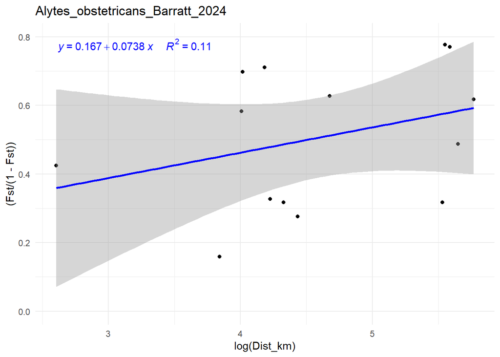

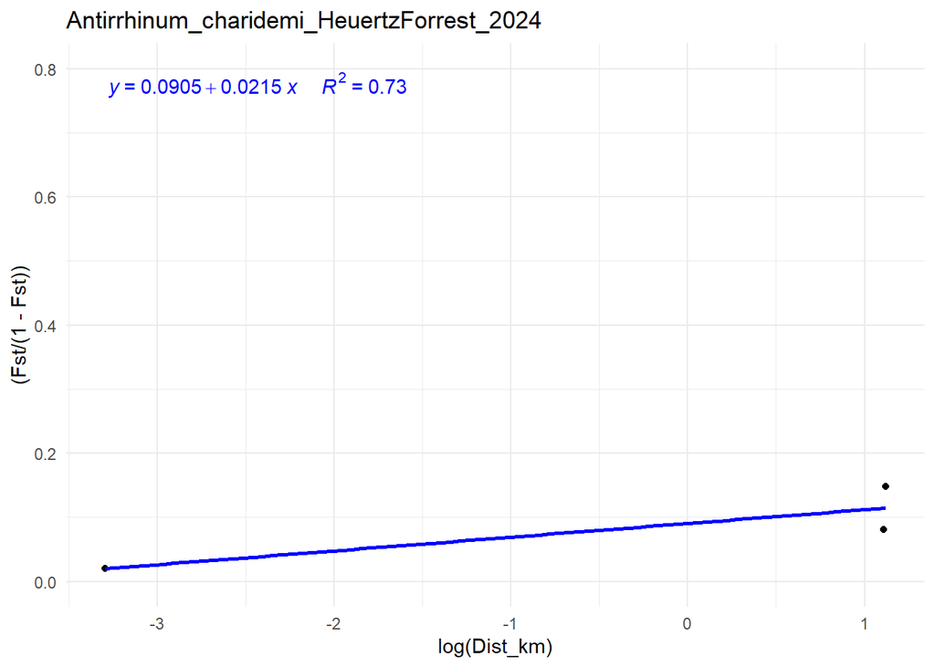

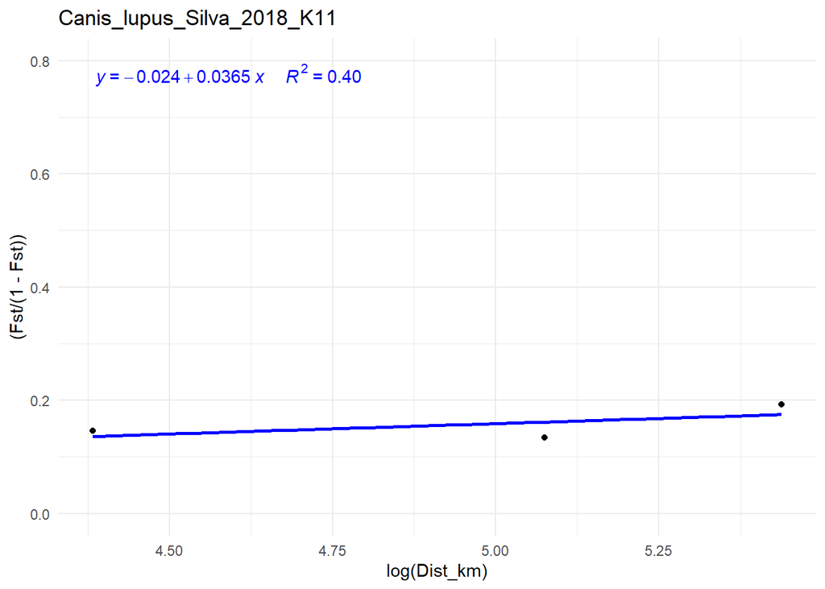

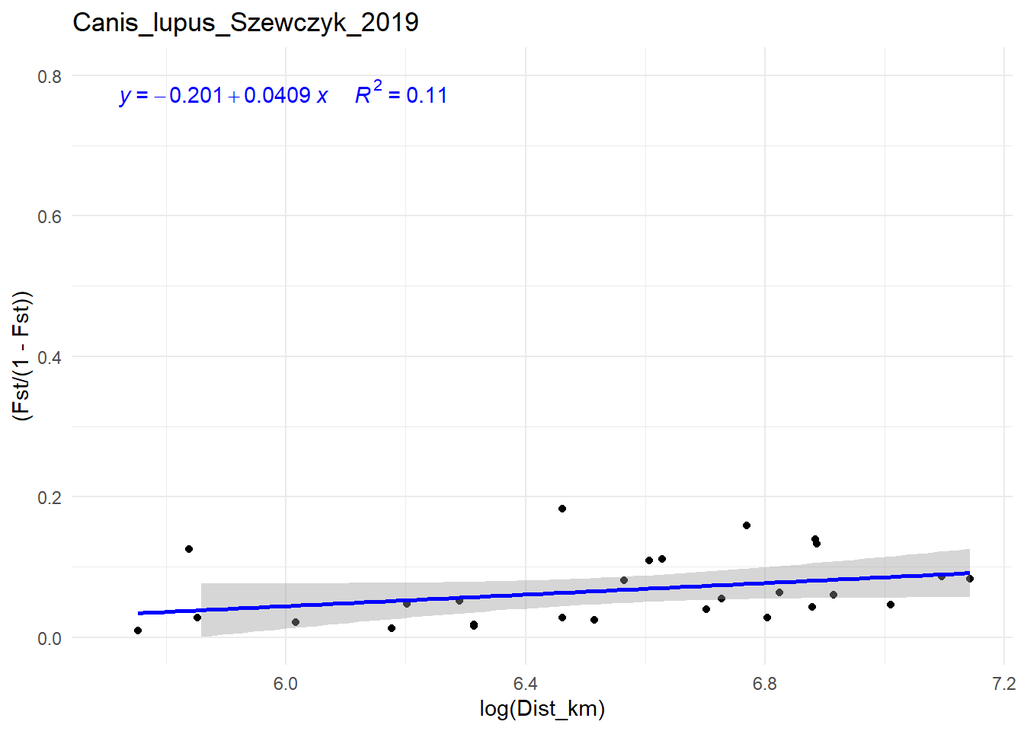

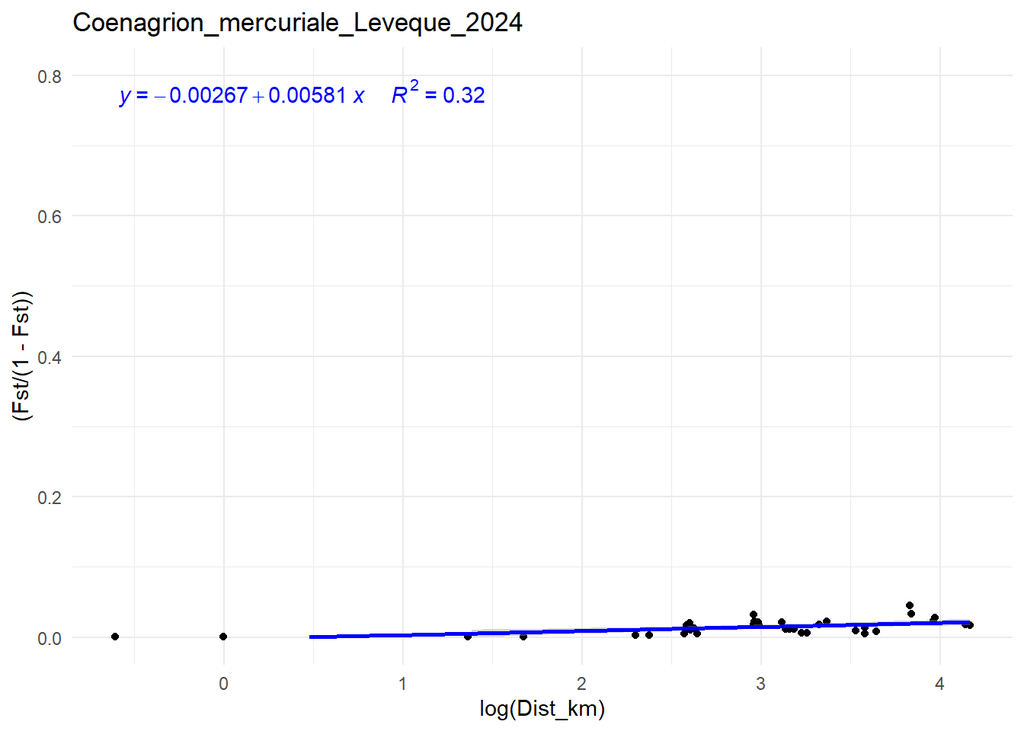

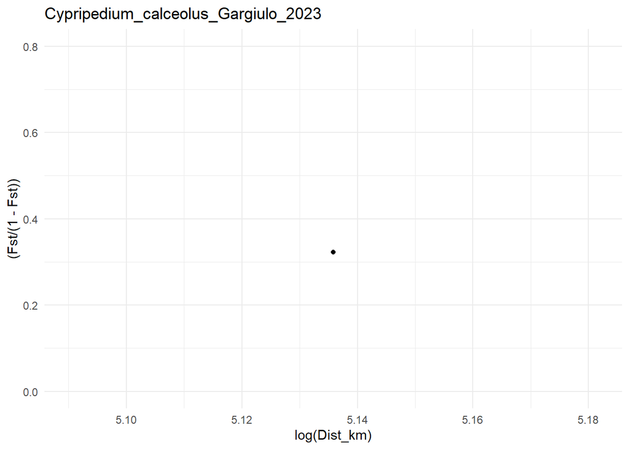

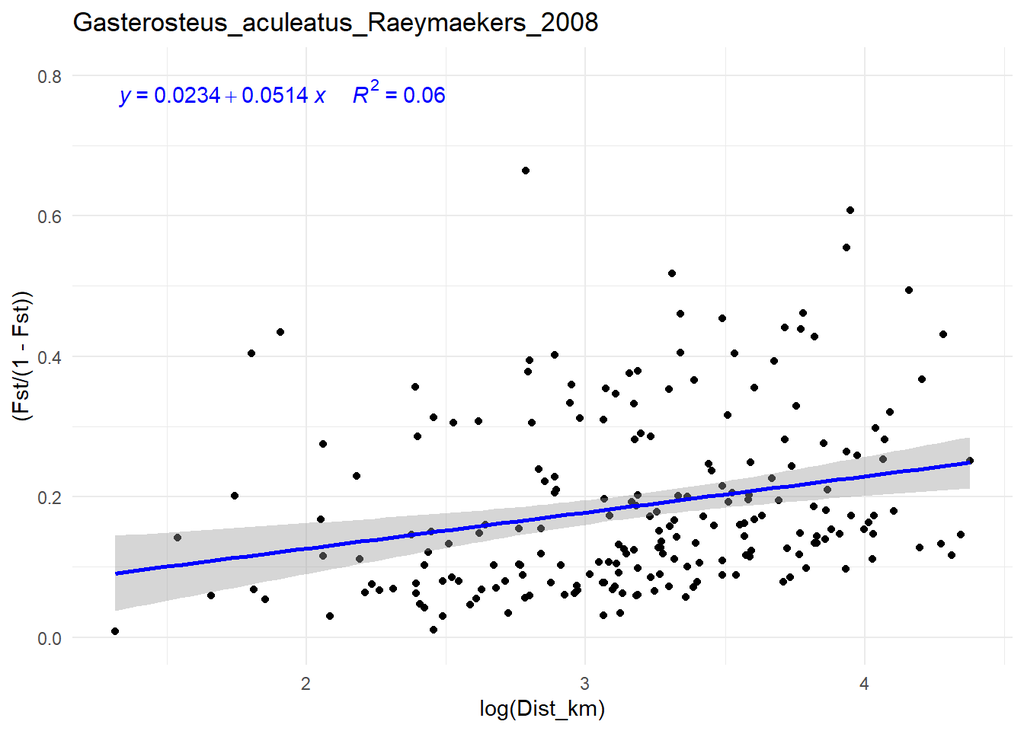

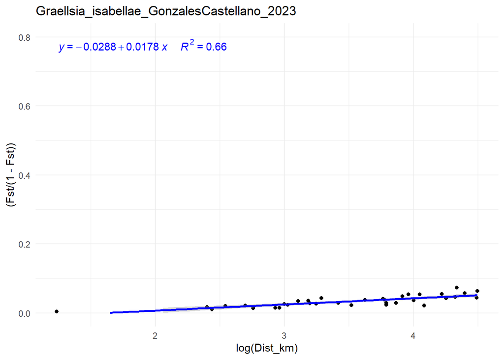

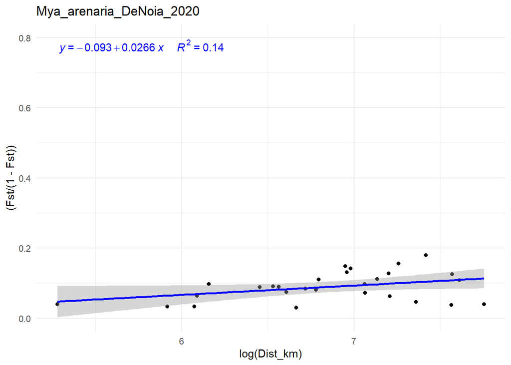

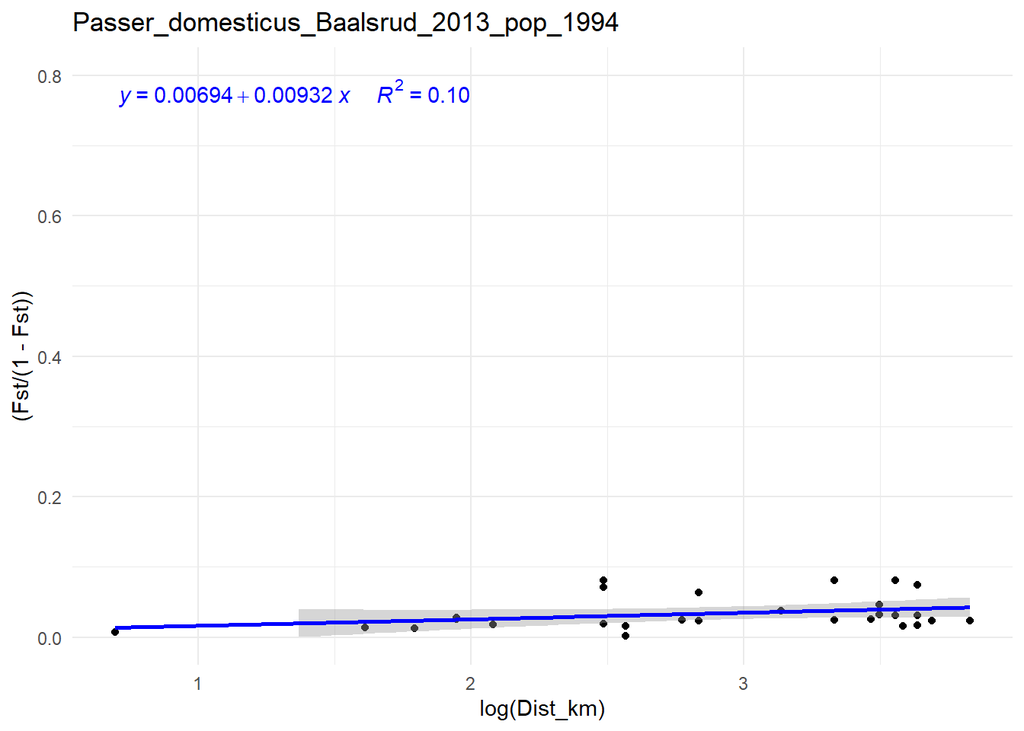

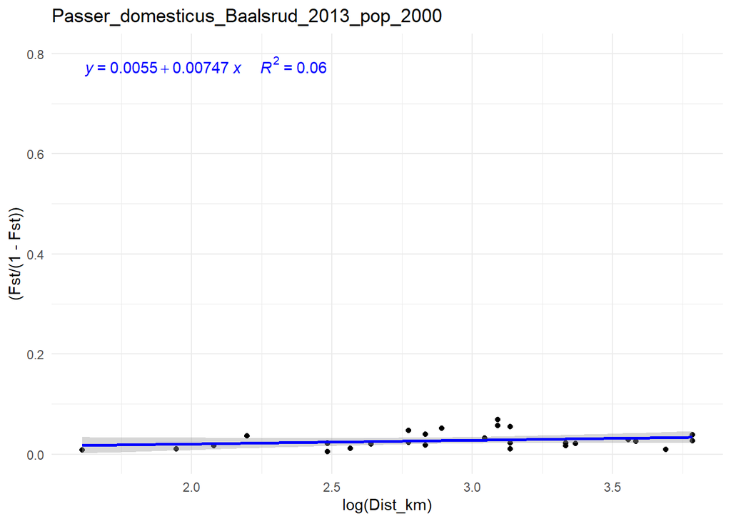

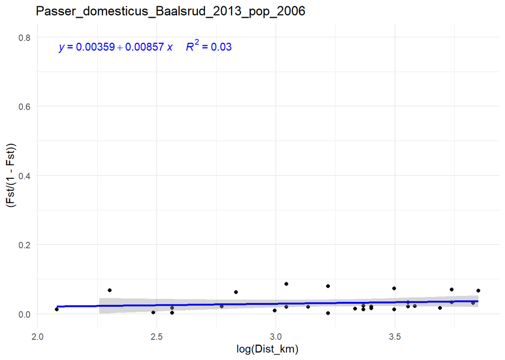

[2 more figures not shown]

```r
for (i in names(microsat_df_pop_2by2_Fst_dist)){
  df <- microsat_df_pop_2by2_Fst_dist[[i]]
  g <- ggplot(df,aes(x=log(Dist_km),y=(Fst/(1-Fst))))+geom_point()+
    geom_smooth(method = "lm", color = "blue") +
    stat_poly_eq(
    formula = y ~ x,
    aes(label = paste(..eq.label.., ..rr.label.., sep = "~~~~~")),
    colour = "blue") +
  ggtitle(i)+
    ylim(0,0.8)+
  theme_minimal()
  print(g)
}
```

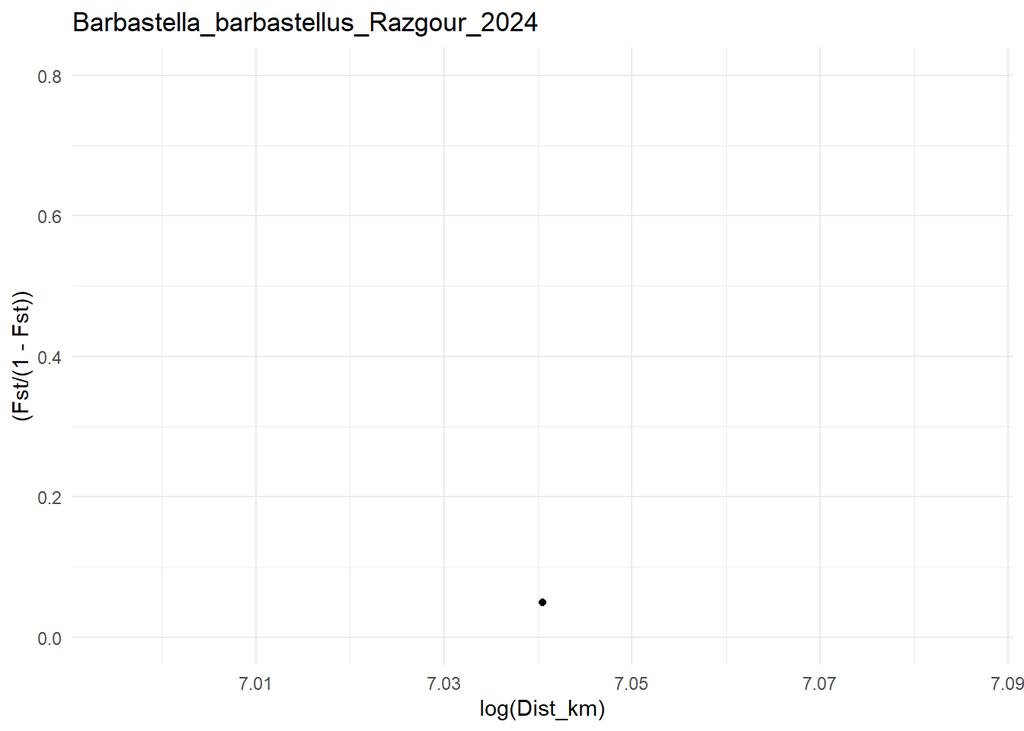

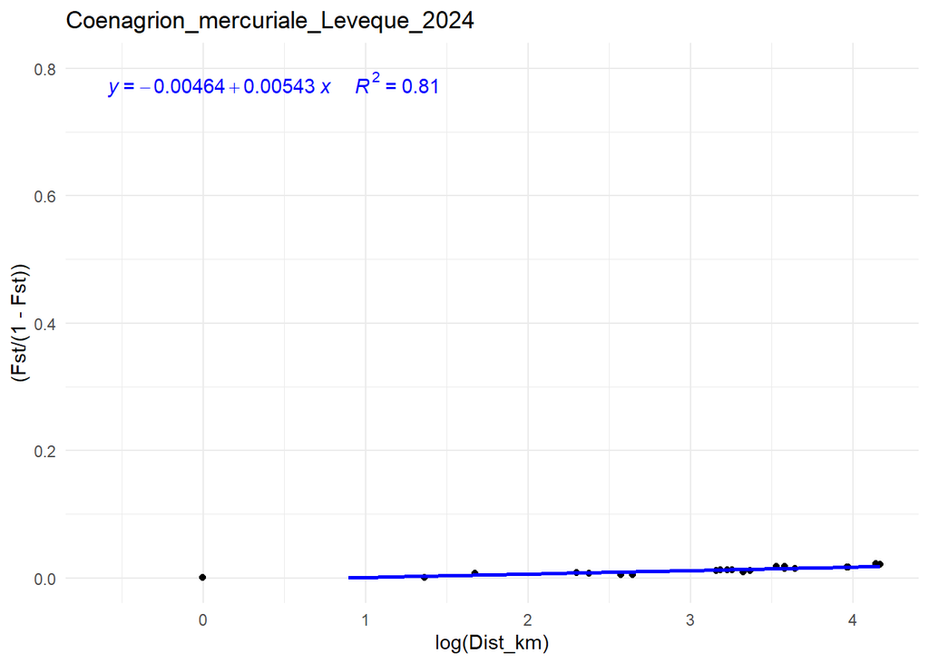

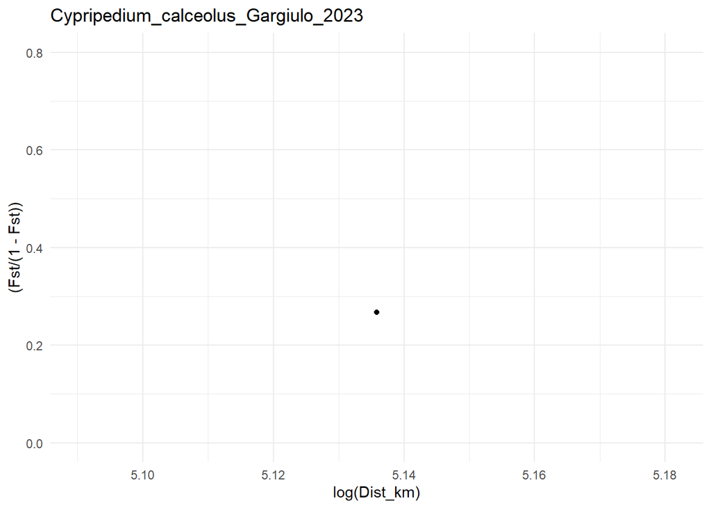

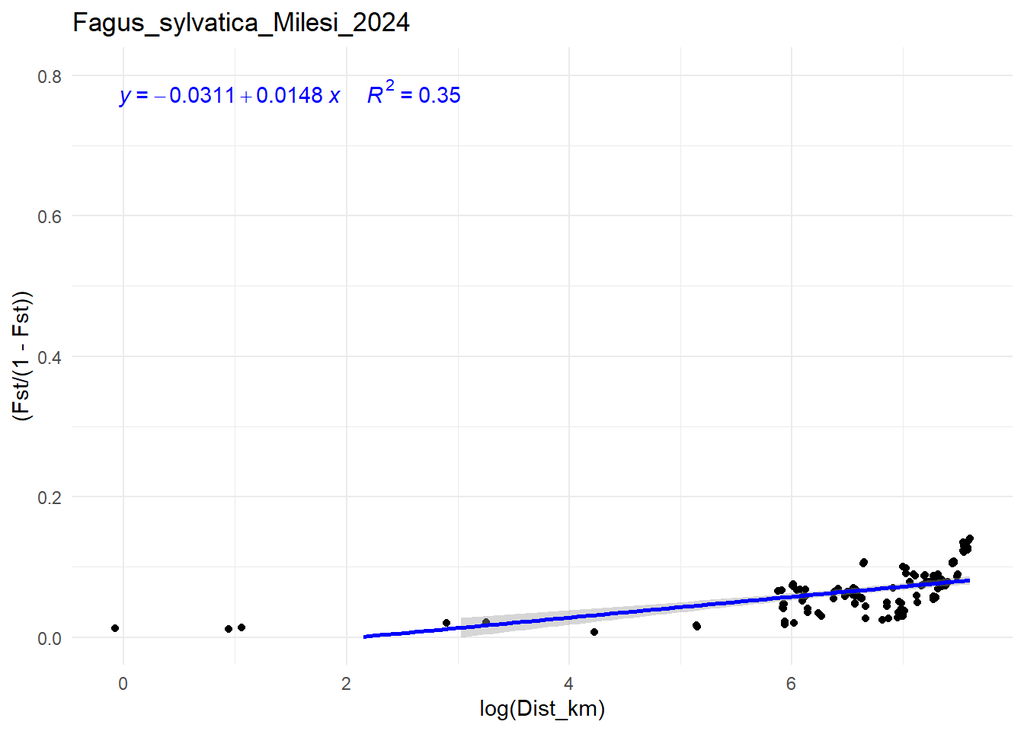

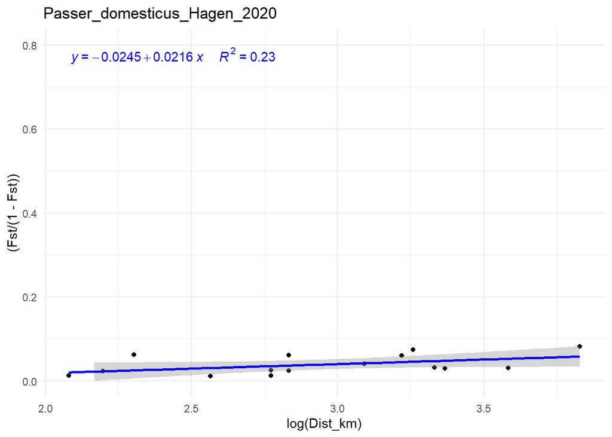

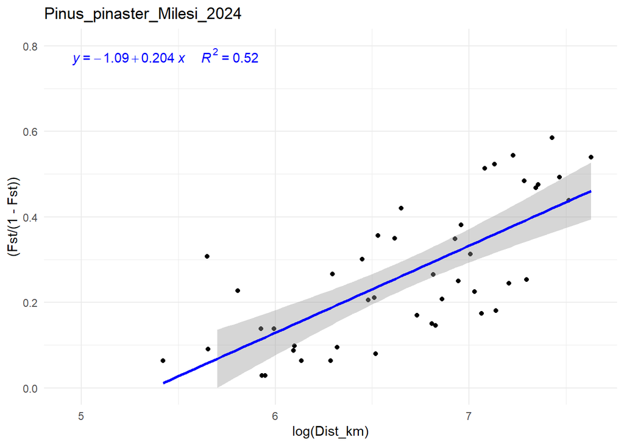

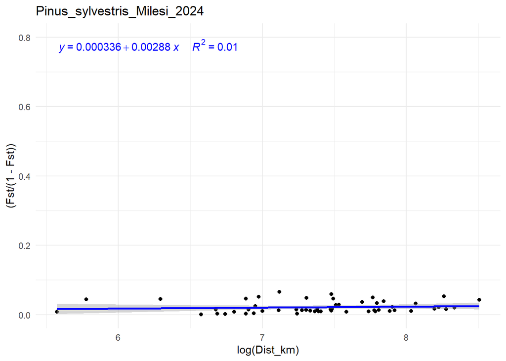

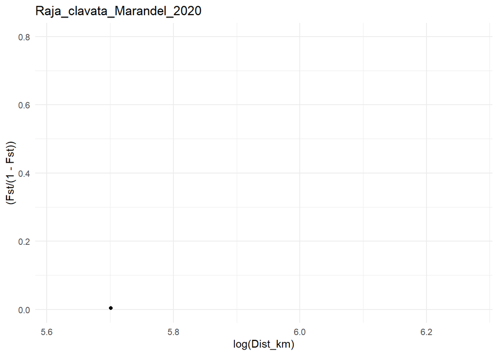

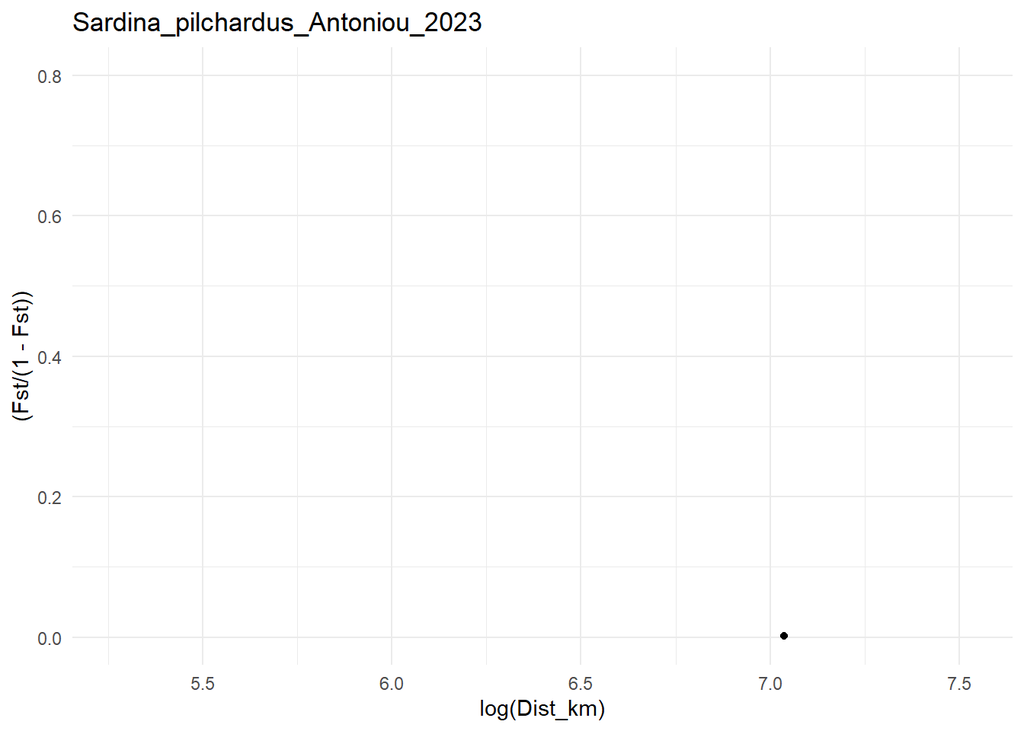

```r
for (i in names(snps_df_pop_2by2_Fst_dist)){
  df <- snps_df_pop_2by2_Fst_dist[[i]]
  g <- ggplot(df,aes(x=log(Dist_km),y=(Fst/(1-Fst))))+geom_point()+
    geom_smooth(method = "lm", color = "blue") +
    stat_poly_eq(
    formula = y ~ x,
    aes(label = paste(..eq.label.., ..rr.label.., sep = "~~~~~")),
    colour = "blue") +
  ggtitle(i)+
    ylim(0,0.8)+
  theme_minimal()
  print(g)
}
```

## 3.4 Gather the regression coeff of IBD in a table

As in Milesi et al. 2024 –> following the Rousset approach for a two-dimensional stepping-stone model: Fst/(1-Fst)=b*log(dist)+a+er

```r
#replace negative Fst by 0
microsat_df_pop_2by2_Fst_dist_2 <- map(microsat_df_pop_2by2_Fst_dist, ~ .x %>% mutate(Fst = pmax(Fst, 0)))
snps_df_pop_2by2_Fst_dist_2 <- map(snps_df_pop_2by2_Fst_dist, ~ .x %>% mutate(Fst = pmax(Fst, 0)))


IBD_coeff_Rousset <- matrix(ncol=8,nrow=0)
colnames(IBD_coeff_Rousset) <- c("Dataset","Marker_type","a_intercept","pval_a_intercept","b_slope","pval_b_slope","R2","R2_adjusted")

## Microsat
Marker_type="microsat"
for (i in 1:length(microsat_df_pop_2by2_Fst_dist_2)){

  dat=microsat_df_pop_2by2_Fst_dist_2[[i]]
  #sometimes, distance are very small and interpreted as zero
  dat <- dat %>% mutate(Dist_km=case_when(Dist_km == 0 ~ 0.00000001,
                                          TRUE ~ Dist_km))


  #Linear model: Fst/(1-Fst)=b*log(dist)+a+er
  mod <- lm((Fst/(1 - Fst)) ~ log(Dist_km), data = dat)

  IBD_coeff_Rousset <- rbind(IBD_coeff_Rousset,
                             c(names(microsat_df_pop_2by2_Fst_dist_2)[[i]],#name of the dataset
                               Marker_type,
                               summary(mod)$coefficients[1,1],#intercept coeff
                               summary(mod)$coefficients[1,4],#intercept p-value
                               ifelse(nrow(summary(mod)$coefficients) >= 2,summary(mod)$coefficients[2, 1],"NA"),#slope coeff
                               ifelse(nrow(summary(mod)$coefficients) >= 2,summary(mod)$coefficients[2, 4],"NA"),#slope p-value
                               summary(mod)$r.squared,#R2
                               summary(mod)$adj.r.squared #R2-adjusted
                               ))

}


## SNPs
Marker_type="snps"
for (i in 1:length(snps_df_pop_2by2_Fst_dist)){

  dat=snps_df_pop_2by2_Fst_dist[[i]]
  #sometimes, distance are very small and interpreted as zero
  dat <- dat %>% mutate(Dist_km=case_when(Dist_km == 0 ~ 0.00000001,
                                          TRUE ~ Dist_km))


  #Linear model: Fst/(1-Fst)=b*log(dist)+a+er
  mod <- lm((Fst/(1 - Fst)) ~ log(Dist_km), data = dat)

  IBD_coeff_Rousset <- rbind(IBD_coeff_Rousset,
                             c(names(snps_df_pop_2by2_Fst_dist)[[i]],#name of the dataset
                               Marker_type,
                               summary(mod)$coefficients[1,1],#intercept coeff
                               summary(mod)$coefficients[1,4],#intercept p-value
                               ifelse(nrow(summary(mod)$coefficients) >= 2,summary(mod)$coefficients[2, 1],"NA"),#slope coeff
                               ifelse(nrow(summary(mod)$coefficients) >= 2,summary(mod)$coefficients[2, 4],"NA"),#slope p-value
                               summary(mod)$r.squared,#R2
                               summary(mod)$adj.r.squared #R2-adjusted
                               ))

  }
```

Save this table

```r
# add a column with IBD_slope x 10^(-3)
IBD_coeff_Rousset <- as.data.frame(IBD_coeff_Rousset)
IBD_coeff_Rousset <- IBD_coeff_Rousset %>% mutate(IBD_slope_10_3=as.numeric(b_slope)*(10^(3)))
#save
write.csv(IBD_coeff_Rousset, file="IBD_snps_microsat_Rousset_reg.csv")
```